# Predicting House Prices in Ames,Iowa

by final project Duo: Terry and Rithvic

2025-12-01

## Research Question

To what extent do House features (e.g., living area, overall quality) versus locational features (neighbourhood) explain variation in house prices in Ames, Iowa? Our aim with this project is to determine whether house features or location-based variables are better predictors of housing prices.

## About the data

Our project used three data sets which were subsets of the Ames Housing Data, which explores variables ranging from internal and external housing factors. We aim to locate variable’s which have the greatest correlation with the housing prices.

We cleaned the data using the tidyverse package and split the variables into category A being ‘Housing features’ involving variables OverallQuality, GrLivArea, YearBuilt and category B, being ‘Location Variables’, which includes the variables Neighborhood, LotFrontage and MSZoning.

To strengthen the modelling process and address distributional challenges, two new engineered variables were introduced:

log_saleprice: Natural log of SalePrice to better fit linear models

Mag_Price: Binary classification of SalePrice, labelled each house as either “High” or “Low”

We also recoded OverallQual into three descriptive quality categories (“Low”, “Med”, “High”) for clearer interpretation.

| Variable | Type | Description |
| --- | --- | --- |
| OverallQual | Categorical | Reclassified overall finish and quality of the home |
| GrLivArea | Numeric | Living area in square feet |
| YearBuilt | Numeric | Year the house was originally built |
| Neighborhood | Categorical | Residential neighborhood where the home is located |
| MSZoning | Categorical | Zoning classification for land use |
| LotFrontage | Numeric | Linear feet of street-connected property frontage |
| log_saleprice | Numeric | Natural log of SalePrice |
| Mag_Price | Categorical | Binary classification of SalePrice |

## Exploratory Analysis

To examine potential correlations between predictors and sale prices, scatter plots and box plots were constructed depending on variable type—continuous variables were plotted against log-transformed prices, whereas categorical variables used grouped boxplots.

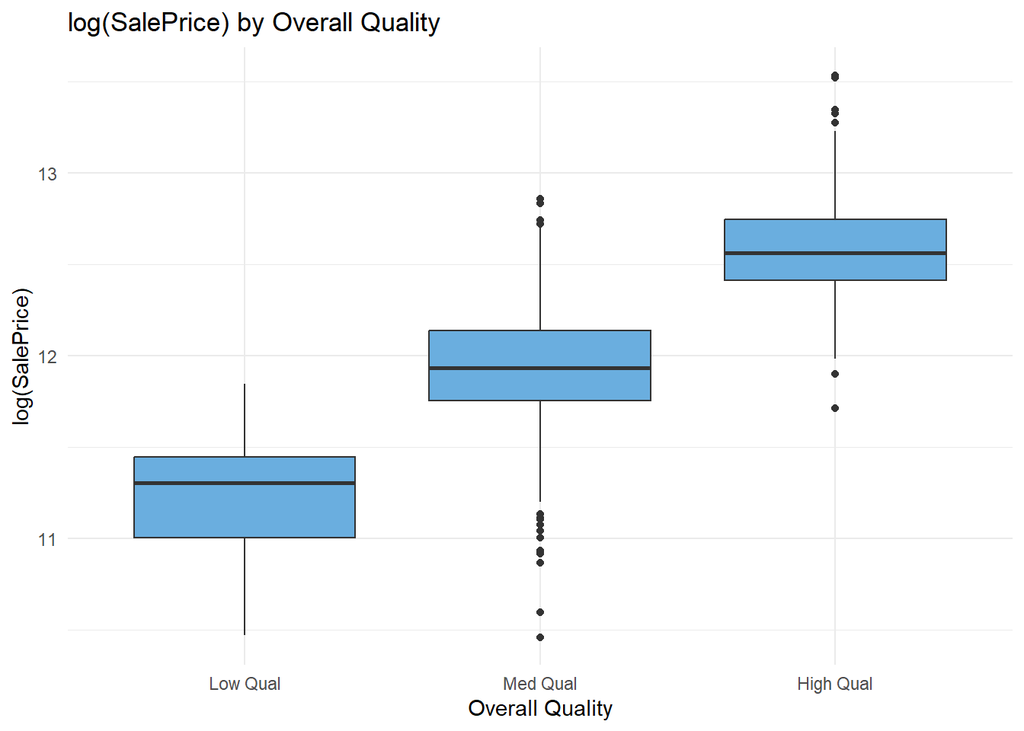

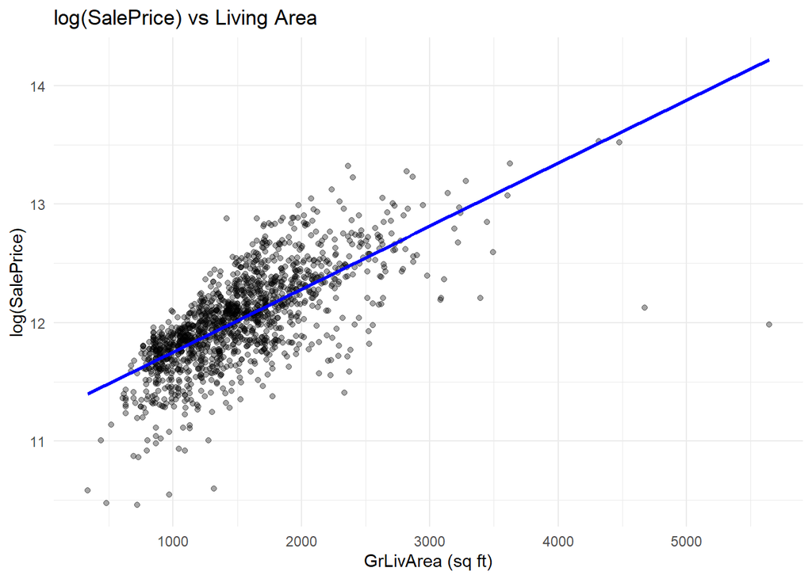

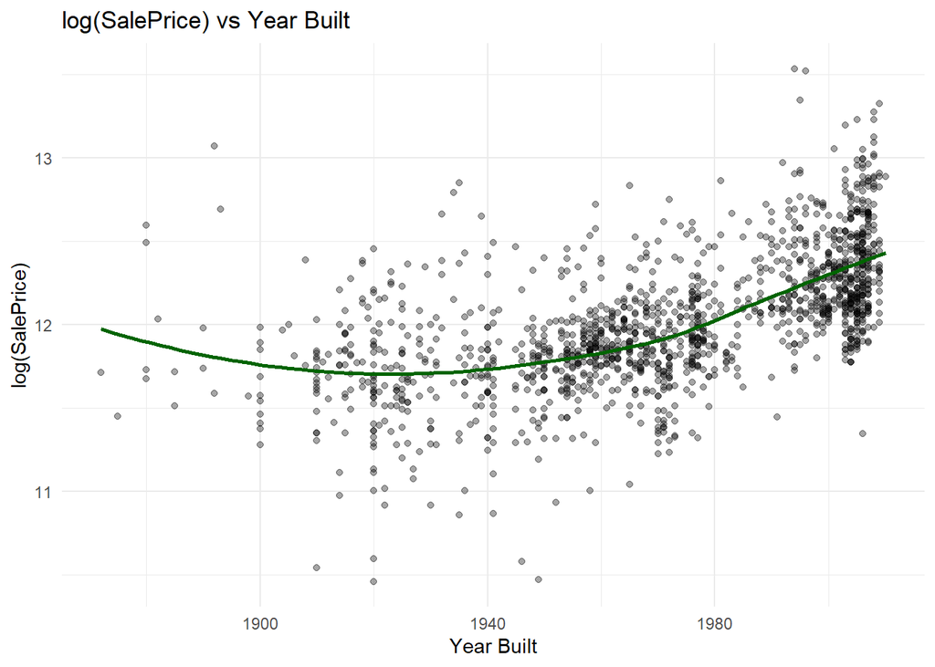

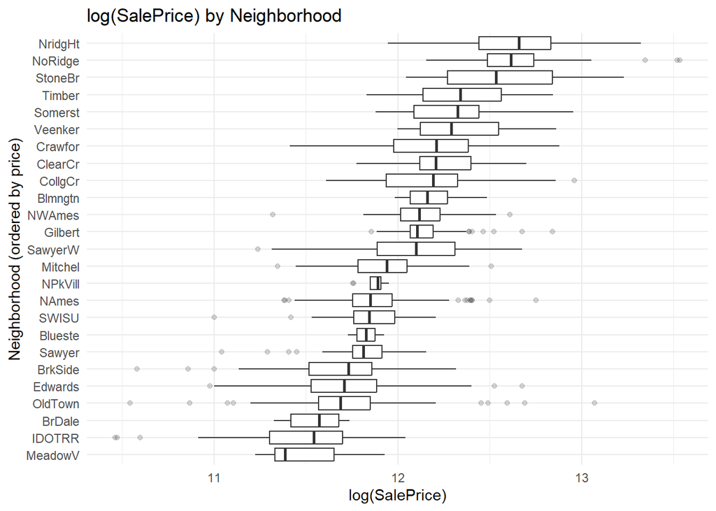

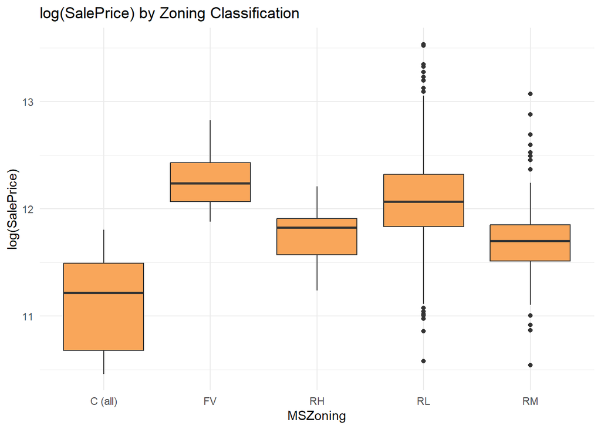

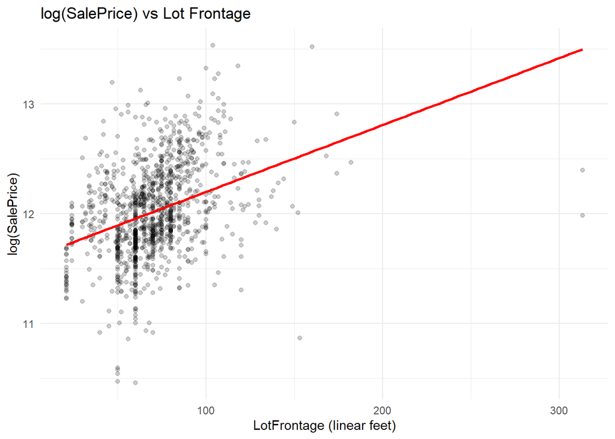

YearBuilt, however, presented a more complex pattern. When considering the entire range from late 1800s to 2000s, the relationship is nonlinear. A curved line of best fit indicates fluctuations in price for older homes; some homes built before the 1940s appear to command higher prices despite age, likely due to architectural charm or “vintage value.” But when focusing on homes built after the 1940s, a more consistent positive correlation emerges, indicating newer constructions tend to command higher prices due to modern materials and updated structural standards.

Neighborhood, plotted by descending median price, displayed strong differences in central tendency. Some neighborhoods clearly command higher baseline prices, but high variability within each group complicates predictive power. Certain neighborhoods also had very few observations, introducing sparsity issues that potentially weaken logistic modelling unless dummy variables are carefully handled.

MSZoning, analysed through boxplots, showed distinct clusters of sale prices among residential zones (e.g., RL, RM, C, etc.). Although zoning categories demonstrate differences in median price ranges, many classes overlap substantially, limiting discriminatory power compared to Group A variables.

## Modelling Approach

Our dataset came with two different files train and test, so we did not have to do the split ourselves. Since the outcome variable Mag_Price is binary, logistic regression was selected as the predictive method for both Group A and Group B models.

```r
log_model <- logistic_reg() %>% set_engine("glm")
```

A key preprocessing step in both models was step_dummy, which converts categorical variables into dummy (one-hot) numeric indicators. This was particularly essential for Group B, which contains Neighborhood and MSZoning, both high-cardinality factors.

```r
rec_A <- recipe(
  Mag_Price ~
    GrLivArea + OverallQual + YearBuilt,
  data = train
) %>%
  step_dummy(all_nominal_predictors())
```

Group B additionally required step_unknown, a safeguard against new or unseen factor levels appearing in the test set that were not present in the training set. This ensures model stability and prevents errors during prediction.

```r
rec_B <- recipe(
  Mag_Price ~
    Neighborhood + MSZoning + LotFrontage,
  data = train
) %>%
  step_unknown(all_nominal_predictors()) %>%
  step_dummy(all_nominal_predictors())
```

We then created a model workflow for both groups (group A is shown):

```r
wf_A <- workflow() %>%
  add_model(log_model) %>%
  add_recipe(rec_A)
```

And fit the model:

```r
fit_A <- wf_A %>%
  fit(data = train)
```

## Model Evaluation

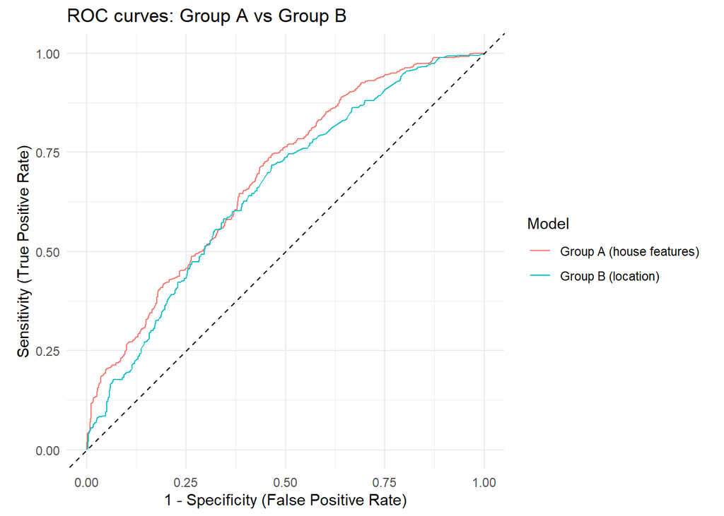

Although the difference between AUC scores was small, Group A consistently achieved a higher AUC than Group B, suggesting housing features contain slightly stronger predictive information for binary classification of prices. However, the gap was narrow enough that we could not confidently claim housing features are definitively superior predictors—only that, numerically, they seem marginally more effective.

## Conclusion

As demonstrated by the comparison in AUC, we are certain that there are distinct positive correlations between both housing features and location variables against sale prices. However, we are also certain that they are not sole explanatory variables. We have neglected complex reasoning such as Ames being a college oriented town and the house sales taking place during the height of the 2008 financial crisis where by considering their influence on our variables makes a complicated and more accurate model.

## References

“House Prices - Advanced Regression Techniques.” Link - https://www.kaggle.com/competitions/house-prices-advanced-regression-techniques/overview